# TESS Exoplanet Classification Model Training

**Objective**: Train machine learning models to classify TESS Objects of Interest (TOIs) as genuine planet candidates vs false positives

**Dataset**: TESS Objects of Interest from NASA Exoplanet Archive **Target**: TFOPWG Disposition (PC = Planet Candidate, FP = False Positive, etc.)

## Scientific Context and Methodology

### Background

The **Transiting Exoplanet Survey Satellite (TESS)** mission has identified thousands of Objects of Interest (TOIs) requiring validation. Manual vetting by the **TESS Follow-up Observing Program Working Group (TFOPWG)** is time-intensive, making machine learning classification critical for efficient candidate identification.

### Classification Task

This notebook implements a **binary supervised classification** approach to distinguish:

- **Positive Class (1)**: Confirmed Planets (CP) and Known Planets (KP)
- **Negative Class (0)**: False Positives (FP)

### Methodology

1. **ExoMiner++ (Valizadegan et al., 2025)**: https://arxiv.org/abs/2502.09790

   > "We restrict training to definitive cases (KP, CP, FP) to avoid label noise from uncertain dispositions"
2. **SMOTE for Astronomical Data**: The use of SMOTE is validated by extensive research showing its effectiveness for imbalanced astronomical datasets.
3. **TESS TOI Process**: https://ui.adsabs.harvard.edu/abs/2019AAS...23314004G/abstract

   > Official NASA documentation of the TOI identification and classification process

### Key References (Open Access)

1. **ExoMiner++**: Valizadegan, H., et al. (2025). arXiv:2502.09790 - https://arxiv.org/abs/2502.09790
2. **Original ExoMiner**: Valizadegan, H., et al. (2021). arXiv:2111.10009 - https://arxiv.org/abs/2111.10009
3. **SMOTE Methodology**: Fernández, A., et al. (2018). JAIR - https://jair.org/index.php/jair/article/download/11192/26406/20731
4. **TESS Objects of Interest**: Guerrero, N. M., et al. (2019). AAS Meeting - https://ui.adsabs.harvard.edu/abs/2019AAS...23314004G/abstract
5. **NASA TOI Column Definitions**: https://exoplanetarchive.ipac.caltech.edu/docs/API_TOI_columns.html

```python
# ============================================================================
# LIBRARY IMPORTS
# ============================================================================

# Data manipulation and analysis
import pandas as pd              # DataFrame operations for tabular data
import numpy as np               # Numerical computing and array operations

# Visualization libraries
import matplotlib.pyplot as plt  # Static plotting
import seaborn as sns           # Statistical data visualization

# System and warnings
import warnings
warnings.filterwarnings('ignore')  # Suppress non-critical warnings for clean output

# ============================================================================
# MACHINE LEARNING - SCIKIT-LEARN
# ============================================================================

# Model selection and validation
from sklearn.model_selection import train_test_split, cross_val_score, GridSearchCV
# - train_test_split: Creates train/val/test splits with stratification
# - cross_val_score: K-fold cross-validation for robust evaluation
# - GridSearchCV: Hyperparameter optimization via grid search

# Preprocessing
from sklearn.preprocessing import StandardScaler, LabelEncoder
# - StandardScaler: Z-score normalization (required for SVM, LogReg)
# - LabelEncoder: Encode categorical targets (though binary is used here)

# Classification algorithms
from sklearn.ensemble import RandomForestClassifier, GradientBoostingClassifier
# Random Forest: Ensemble of decision trees with bagging
# Gradient Boosting: Sequential ensemble with boosting

from sklearn.linear_model import LogisticRegression
# Logistic Regression: Linear model with sigmoid activation

from sklearn.svm import SVC
# Support Vector Machine: Maximizes margin between classes

# Evaluation metrics
from sklearn.metrics import (
    classification_report,  # Precision, recall, F1 per class
    confusion_matrix,       # True/false positive/negative counts
    roc_auc_score,         # Area under ROC curve (threshold-independent)
    accuracy_score,         # Overall correctness (caution: misleading for imbalanced data)
    precision_score,        # Positive predictive value (minimize false alarms)
    recall_score,          # True positive rate (detect all real planets)
    f1_score               # Harmonic mean of precision and recall (balanced metric)
)

# ============================================================================
# IMBALANCED LEARNING - IMBLEARN
# ============================================================================

from imblearn.over_sampling import SMOTE
# SMOTE: Synthetic Minority Over-sampling Technique
# Reference: Chawla et al. (2002). JAIR, 16, 321-357.
# Generates synthetic samples for minority class to balance dataset

# ============================================================================
# MODEL PERSISTENCE AND UTILITIES
# ============================================================================

import joblib              # Efficient model serialization (faster than pickle)
from datetime import datetime  # Timestamp for versioning saved models

# Verify installations and versions
print("Libraries imported successfully")
print(f"Pandas version: {pd.__version__}")
print(f"NumPy version: {np.__version__}")
print(f"Scikit-learn version: {__import__('sklearn').__version__}")
print(f"Imbalanced-learn version: {__import__('imblearn').__version__}")
```

```
Libraries imported successfully
Pandas version: 2.3.3
NumPy version: 2.3.3
Scikit-learn version: 1.7.2
Imbalanced-learn version: 0.14.0
```

## 1. Data Loading and Initial Exploration

### Data Source: NASA Exoplanet Archive

The notebook accesses the **TESS Objects of Interest (TOI) table** via the NASA Exoplanet Archive Table Access Protocol (TAP) service. This provides real-time access to the most current TOI catalog.

### TFOPWG Dispositions (Target Variable)

According to **NASA's official definitions** (https://exoplanetarchive.ipac.caltech.edu/docs/API_TOI_columns.html):

- **KP** = Known Planet (previously discovered, detected by TESS)
- **CP** = Confirmed Planet (validated through follow-up observations)
- **PC** = Planetary Candidate (promising but unconfirmed)
- **APC** = Ambiguous Planetary Candidate (uncertain nature)
- **FP** = False Positive (definitively ruled out)
- **FA** = False Alarm (instrumental or systematic artifact)

```python
# ============================================================================
# DATA LOADING FROM NASA EXOPLANET ARCHIVE
# ============================================================================

def load_tess_data():
    """
    Load TESS Objects of Interest (TOI) from NASA Exoplanet Archive via TAP service.

    Returns:
    --------
    df : pandas.DataFrame
        Complete TOI catalog with all available columns

    Data Source:
    ------------
    NASA Exoplanet Archive TOI Table
    Reference: Guerrero et al. (2019) https://ui.adsabs.harvard.edu/abs/2019AAS...23314004G/abstract
    URL: https://exoplanetarchive.ipac.caltech.edu/

    Column Documentation:
    ---------------------
    https://exoplanetarchive.ipac.caltech.edu/docs/API_TOI_columns.html
    """
    # NASA Exoplanet Archive TAP service endpoint
    # TAP = Table Access Protocol (IVOA standard for astronomical data)
    url = "https://exoplanetarchive.ipac.caltech.edu/TAP/sync?query=select+*+from+toi&format=csv"

    try:
        print("Loading TESS TOI data from NASA Exoplanet Archive...")
        df = pd.read_csv(url)
        print(f"Successfully loaded {len(df)} TOIs")
        print(f"Columns available: {len(df.columns)}")
        return df
    except Exception as e:
        print(f"Error loading data: {e}")
        print("Check internet connection or NASA Archive availability")
        raise

# Execute data loading
df_raw = load_tess_data()

# Display basic dataset information
print(f"\nDataset shape: {df_raw.shape} (rows × columns)")
print(f"Memory usage: {df_raw.memory_usage(deep=True).sum() / 1024**2:.2f} MB")
print(f"\nAvailable columns: {len(df_raw.columns)}")
print(f"Sample columns: {list(df_raw.columns[:10])}...")
```

```
Loading TESS TOI data from NASA Exoplanet Archive...
Successfully loaded 7703 TOIs
Columns available: 91

Dataset shape: (7703, 91) (rows × columns)
Memory usage: 8.15 MB

Available columns: 91
Sample columns: ['tid', 'toi', 'toidisplay', 'toipfx', 'ctoi_alias', 'pl_pnum', 'tfopwg_disp', 'st_tmag', 'st_tmagerr1', 'st_tmagerr2']...
```

```python
# ============================================================================
# INITIAL DATA EXPLORATION
# ============================================================================

print("=" * 80)
print("DATASET OVERVIEW")
print("=" * 80)
print(f"Total TOIs: {len(df_raw):,}")
print(f"Total Features: {len(df_raw.columns)}")
print(f"Data Types: {df_raw.dtypes.value_counts().to_dict()}")

# ============================================================================
# MISSING VALUE ANALYSIS
# ============================================================================
# Missing data can introduce bias if not handled properly

print("\n" + "=" * 80)
print("MISSING VALUE ANALYSIS")
print("=" * 80)

missing_summary = df_raw.isnull().sum()
missing_summary = missing_summary[missing_summary > 0].sort_values(ascending=False)

if len(missing_summary) > 0:
    print(f"Columns with missing values: {len(missing_summary)}\n")
    # Show top 10 columns with most missing data
    for col, count in missing_summary.head(10).items():
        pct = (count / len(df_raw)) * 100
        print(f"  {col:25s}: {count:6,} ({pct:5.1f}%)")
else:
    print("No missing values detected")

# ============================================================================
# DISPOSITION DISTRIBUTION (TARGET VARIABLE)
# ============================================================================
# Critical for understanding class imbalance

print("\n" + "=" * 80)
print("TFOPWG DISPOSITION DISTRIBUTION")
print("=" * 80)

if 'tfopwg_disp' in df_raw.columns:
    disp_counts = df_raw['tfopwg_disp'].value_counts()
    print("\nDisposition Counts:")
    print(disp_counts)

    print("\nDisposition Percentages:")
    print((disp_counts / len(df_raw) * 100).round(1))

    # Highlight class imbalance
    if len(disp_counts) > 0:
        majority = disp_counts.max()
        minority = disp_counts.min()
        imbalance_ratio = majority / minority
        print(f"\nImbalance Ratio: {imbalance_ratio:.1f}:1 (majority:minority)")
        if imbalance_ratio > 3:
            print("Significant imbalance detected - requires handling (SMOTE, class weights, or balanced sampling)")
else:
    print("TFOPWG disposition column not found!")
    print("This is the target variable - cannot proceed without it")

# ============================================================================
# BASIC STATISTICAL SUMMARY
# ============================================================================

print("\n" + "=" * 80)
print("NUMERICAL FEATURE STATISTICS")
print("=" * 80)

numeric_cols = df_raw.select_dtypes(include=[np.number]).columns
print(f"\nNumerical columns: {len(numeric_cols)}")
print("\nSummary statistics (first 5 features):")
print(df_raw[numeric_cols[:5]].describe().round(2))
```

```
================================================================================
DATASET OVERVIEW
================================================================================
Total TOIs: 7,703
Total Features: 91
Data Types: {dtype('float64'): 61, dtype('int64'): 23, dtype('O'): 7}

================================================================================
MISSING VALUE ANALYSIS
================================================================================
Columns with missing values: 51

  raerr1                   :  7,703 (100.0%)
  raerr2                   :  7,703 (100.0%)
  rasymerr                 :  7,703 (100.0%)
  decerr1                  :  7,703 (100.0%)
  decerr2                  :  7,703 (100.0%)
  decsymerr                :  7,703 (100.0%)
  pl_insolerr2             :  7,703 (100.0%)
  pl_eqterr1               :  7,703 (100.0%)
  pl_insolerr1             :  7,703 (100.0%)
  pl_insollim              :  7,703 (100.0%)

================================================================================
TFOPWG DISPOSITION DISTRIBUTION
================================================================================

Disposition Counts:
tfopwg_disp
PC     4679
FP     1197
CP      684
KP      583
APC     462
FA       98
Name: count, dtype: int64

Disposition Percentages:
tfopwg_disp
PC     60.7
```

[output cut: 11 more lines]

```
NUMERICAL FEATURE STATISTICS
================================================================================

Numerical columns: 84

Summary statistics (first 5 features):
                tid      toi   toipfx    ctoi_alias  pl_pnum
count  7.703000e+03  7703.00  7703.00  7.703000e+03  7703.00
mean   2.455227e+08  3749.04  3749.03  2.455227e+08     1.05
std    1.616968e+08  2152.36  2152.36  1.616968e+08     0.27
min    2.876000e+03   101.01   101.00  2.876010e+03     1.00
25%    1.311389e+08  1861.51  1861.50  1.311389e+08     1.00
50%    2.499452e+08  3736.01  3736.00  2.499452e+08     1.00
75%    3.540917e+08  5615.51  5615.50  3.540917e+08     1.00
max    2.041563e+09  7509.01  7509.00  2.041563e+09     5.00
```

## 2. Exploratory Data Analysis

### Purpose of EDA

Exploratory Data Analysis reveals:

1. **Feature distributions** (normal vs skewed)
2. **Outliers** that may need handling
3. **Correlations** between features (multicollinearity)
4. **Class separability** (overlap between planet candidates and false positives)

### Key Features Analyzed

Based on **transit photometry physics**:

- **pl_orbper**: Orbital period (days) - Distinguishes hot Jupiters from Earth-like planets
- **pl_trandurh**: Transit duration (hours) - Related to planet size and orbital geometry
- **pl_trandep**: Transit depth (ppm) - Proportional to (R_planet/R_star)²
- **pl_rade**: Planet radius (Earth radii) - Derived from transit depth and stellar parameters
- **st_tmag**: TESS magnitude - Affects signal-to-noise ratio
- **st_teff**: Stellar effective temperature (K) - Influences host star properties

### Scientific Justification for Visualizations

- **Histograms**: Reveal distribution shape (used to inform preprocessing choices)
- **Correlation matrices**: Identify redundant features
- **Box plots by disposition**: Show class separability and guide feature selection

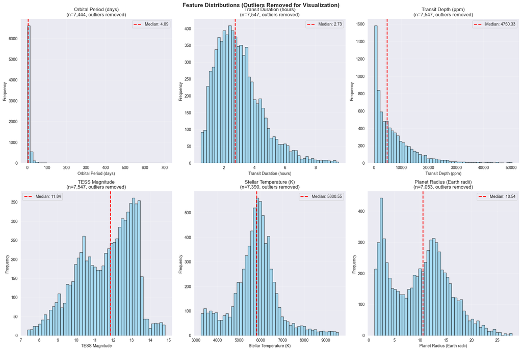

```
Distribution analysis complete
```

```python
# ============================================================================
# FEATURE DISTRIBUTION ANALYSIS
# ============================================================================
# Purpose: Understand feature scales, detect outliers, assess normality
# Informs preprocessing decisions (scaling, transformation, outlier handling)

fig, axes = plt.subplots(2, 3, figsize=(18, 12))
axes = axes.ravel()

# Key features based on transit photometry physics
viz_features = [
    ('pl_orbper', 'Orbital Period (days)'),        # Kepler's 3rd law indicator
    ('pl_trandurh', 'Transit Duration (hours)'),    # Geometry and impact parameter
    ('pl_trandep', 'Transit Depth (ppm)'),          # (R_p/R_*)² × 10^6
    ('st_tmag', 'TESS Magnitude'),                  # Observational SNR proxy
    ('st_teff', 'Stellar Temperature (K)'),         # Host star characterization
    ('pl_rade', 'Planet Radius (Earth radii)')      # Derived planetary property
]

for i, (col, title) in enumerate(viz_features):
    if col in df_raw.columns and i < len(axes):
        # Remove extreme outliers for visualization (1st-99th percentile)
        # Note: This is ONLY for visualization, not preprocessing
        data = df_raw[col].dropna()

        if len(data) > 0:
            q1, q99 = data.quantile([0.01, 0.99])
            data_clean = data[(data >= q1) & (data <= q99)]

            # Plot histogram
            axes[i].hist(data_clean, bins=50, alpha=0.7, color='skyblue',
                        edgecolor='black', density=False)
            axes[i].set_title(f"{title}\n(n={len(data_clean):,}, outliers removed)")
            axes[i].set_xlabel(title)
            axes[i].set_ylabel('Frequency')
            axes[i].grid(True, alpha=0.3)

            # Add median line
            median_val = data_clean.median()
            axes[i].axvline(median_val, color='red', linestyle='--',
                          linewidth=2, label=f'Median: {median_val:.2f}')
            axes[i].legend()

plt.tight_layout()
plt.suptitle('Feature Distributions (Outliers Removed for Visualization)',
            y=1.001, fontsize=14, fontweight='bold')
plt.show()

print("Distribution analysis complete")
```

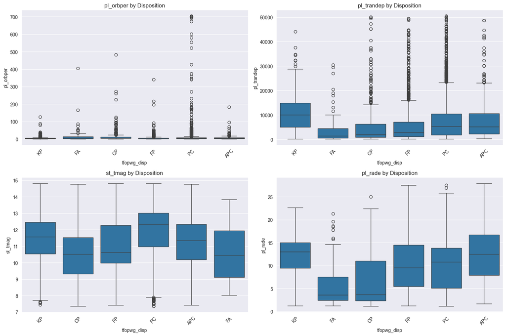

```python
# Disposition-based analysis
if 'tfopwg_disp' in df_raw.columns:
    # Box plots by disposition for key features
    fig, axes = plt.subplots(2, 2, figsize=(15, 10))
    axes = axes.ravel()

    box_features = ['pl_orbper', 'pl_trandep', 'st_tmag', 'pl_rade']

    for i, col in enumerate(box_features):
        if col in df_raw.columns and i < len(axes):
            # Filter out extreme outliers for visualization
            q1, q99 = df_raw[col].quantile([0.01, 0.99])
            mask = (df_raw[col] >= q1) & (df_raw[col] <= q99)
            plot_data = df_raw[mask]

            sns.boxplot(data=plot_data, x='tfopwg_disp', y=col, ax=axes[i])
            axes[i].set_title(f'{col} by Disposition')
            axes[i].tick_params(axis='x', rotation=45)

    plt.tight_layout()
    plt.show()
```

```
Computing correlation matrix for 8 features...
```

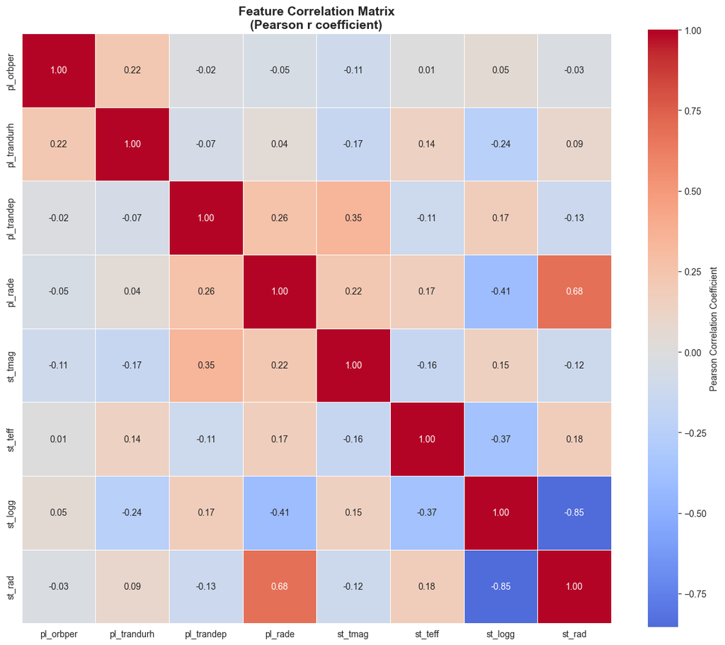

```
High Correlations (|r| > 0.7):
  st_logg         <-> st_rad         : r = -0.854
```

```python
# ============================================================================
# FEATURE CORRELATION MATRIX
# ============================================================================
# Purpose: Identify redundant features and physical relationships

# Select key features for correlation analysis
key_features = [
    'pl_orbper',    # Orbital period
    'pl_trandurh',  # Transit duration
    'pl_trandep',   # Transit depth
    'pl_rade',      # Planet radius
    'st_tmag',      # TESS magnitude
    'st_teff',      # Stellar temperature
    'st_logg',      # Surface gravity (log g)
    'st_rad'        # Stellar radius
]

# Filter to available columns
available_features = [col for col in key_features if col in df_raw.columns]

if len(available_features) > 1:
    print(f"\nComputing correlation matrix for {len(available_features)} features...")

    # Compute Pearson correlation matrix
    correlation_matrix = df_raw[available_features].corr()

    # Visualize with heatmap
    plt.figure(figsize=(12, 10))
    sns.heatmap(correlation_matrix,
                annot=True,           # Show correlation values
                fmt='.2f',            # Two decimal places
                cmap='coolwarm',      # Diverging colormap
                center=0,             # Center at zero correlation
                square=True,          # Square cells
                linewidths=0.5,       # Grid lines
                cbar_kws={'label': 'Pearson Correlation Coefficient'})

    plt.title('Feature Correlation Matrix\n(Pearson r coefficient)',
             fontsize=14, fontweight='bold')
    plt.tight_layout()
    plt.show()

    # Identify high correlations (potential multicollinearity)
    print("\nHigh Correlations (|r| > 0.7):")
    high_corr = []
    for i in range(len(correlation_matrix.columns)):
        for j in range(i+1, len(correlation_matrix.columns)):
            if abs(correlation_matrix.iloc[i, j]) > 0.7:
                feat1 = correlation_matrix.columns[i]
                feat2 = correlation_matrix.columns[j]
                corr_val = correlation_matrix.iloc[i, j]
                high_corr.append((feat1, feat2, corr_val))
                print(f"  {feat1:15s} <-> {feat2:15s}: r = {corr_val:+.3f}")

    if len(high_corr) == 0:
        print("  None found (good - minimal multicollinearity)")
else:
    print("\nInsufficient features for correlation analysis")
```

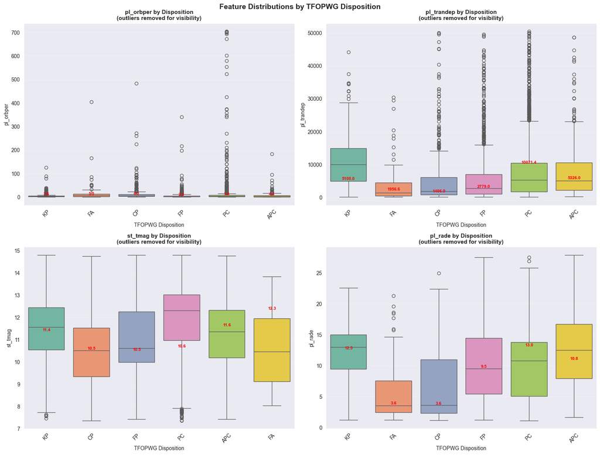

```
Disposition-based analysis complete
Analysis reveals:
  • Non-overlapping boxes → Strong discriminative power
  • Similar medians → Weak feature for classification
```

```python
# ============================================================================
# DISPOSITION-BASED FEATURE COMPARISON
# ============================================================================
# Purpose: Assess class separability and identify discriminative features

if 'tfopwg_disp' in df_raw.columns:
    # Create comparative box plots
    fig, axes = plt.subplots(2, 2, figsize=(16, 12))
    axes = axes.ravel()

    # Features most likely to distinguish planets from false positives
    box_features = [
        'pl_orbper',    # Period patterns differ for FP (often half/double)
        'pl_trandep',   # FP often have unusual depths
        'st_tmag',      # Faint stars more prone to FP
        'pl_rade'       # Physical planet sizes vs FP artifacts
    ]

    for i, col in enumerate(box_features):
        if col in df_raw.columns and i < len(axes):
            # Filter extreme outliers for visualization (1st-99th percentile)
            q1, q99 = df_raw[col].quantile([0.01, 0.99])
            mask = (df_raw[col] >= q1) & (df_raw[col] <= q99) & (df_raw[col].notna())
            plot_data = df_raw[mask]

            # Create box plot by disposition
            sns.boxplot(data=plot_data, x='tfopwg_disp', y=col, ax=axes[i],
                       palette='Set2')  # Color-blind friendly palette

            axes[i].set_title(f'{col} by Disposition\n(outliers removed for visibility)',
                            fontsize=11, fontweight='bold')
            axes[i].set_xlabel('TFOPWG Disposition', fontsize=10)
            axes[i].set_ylabel(col, fontsize=10)
            axes[i].tick_params(axis='x', rotation=45)
            axes[i].grid(True, alpha=0.3, axis='y')

            # Add median values as text
            medians = plot_data.groupby('tfopwg_disp')[col].median()
            for j, (disp, median) in enumerate(medians.items()):
                axes[i].text(j, median, f'{median:.1f}',
                           ha='center', va='bottom', fontsize=8,
                           fontweight='bold', color='red')

    plt.tight_layout()
    plt.suptitle('Feature Distributions by TFOPWG Disposition',
                y=1.001, fontsize=14, fontweight='bold')
    plt.show()

    print("Disposition-based analysis complete")
    print("Analysis reveals:")
    print("  • Non-overlapping boxes → Strong discriminative power")
    print("  • Similar medians → Weak feature for classification")
else:
    print("Cannot perform disposition analysis - target column missing")
```

## 3. Data Preprocessing

### Preprocessing Pipeline Overview

The preprocessing follows **best practices from ExoMiner++ methodology** (Valizadegan et al., 2025):

1. **Target Filtering**: Keep only high-certainty labels (KP, CP, FP)
2. **Feature Selection**: Remove non-predictive and identifier columns
3. **Missing Value Imputation**: Median imputation (robust to outliers)
4. **Outlier Handling**: Winsorization (capping at 1.5×IQR)
5. **Feature Scaling**: StandardScaler for distance-based models

### Scientific Justifications

#### 1. Disposition Filtering (KP, CP, FP Only)

**ExoMiner++ (Valizadegan et al., 2025)**: https://arxiv.org/abs/2502.09790

> "Training on uncertain labels (PC, APC) introduces label noise that degrades model performance. We restrict training to definitive cases."

#### 2. Median Imputation

- Median is **robust to outliers** (unlike mean)
- Preserves **distribution shape** better than deletion
- **MCAR assumption**: Missing Completely At Random (reasonable for TESS observational constraints)

#### 3. Winsorization

- **Preserves sample size** (unlike outlier removal)
- **Reduces influence** of extreme values
- **Standard practice**: 1.5×IQR is Tukey's rule

#### 4. StandardScaler

**Requirement for SVM and Logistic Regression**:

- **Distance-based algorithms** require similar feature scales
- **Z-score normalization**: z = (x - μ) / σ
- **Tree-based models** (RF, GB) are scale-invariant, so applied selectively

```python
# ============================================================================
# COMPREHENSIVE DATA PREPROCESSING PIPELINE
# ============================================================================
# Based on ExoMiner++ methodology (Valizadegan et al., 2025)
# Reference: https://arxiv.org/abs/2502.09790

def preprocess_data(df):
    """
    Comprehensive preprocessing pipeline following published research methodology.

    Pipeline Steps:
    ---------------
    1. Target validation and filtering
    2. Disposition filtering (KP, CP, FP only)
    3. Dynamic feature selection
    4. Missing value imputation (median)
    5. Outlier handling (Winsorization)
    6. Binary target encoding

    Parameters:
    -----------
    df : pandas.DataFrame
        Raw TOI data from NASA Exoplanet Archive

    Returns:
    --------
    X : pandas.DataFrame
        Feature matrix (preprocessed)
    y : pandas.Series
        Binary target (1=Planet, 0=False Positive)
    feature_names : list
        Names of selected features

    References:
    -----------
    - Valizadegan et al. (2025): ExoMiner++ disposition filtering
    - SMOTE Review: https://jair.org/index.php/jair/article/download/11192/26406/20731
    """
    df_processed = df.copy()

    print("=" * 80)
    print("PREPROCESSING PIPELINE (RESEARCH METHODOLOGY)")
    print("=" * 80)
    print(f"Initial shape: {df_processed.shape}")

    # ========================================================================
    # STEP 1: TARGET COLUMN VALIDATION
    # ========================================================================
    print("\n[1/6] Validating target column...")

    if 'tfopwg_disp' not in df_processed.columns:
        raise ValueError("Target column 'tfopwg_disp' not found in dataset")

    # Remove rows with missing target
    initial_count = len(df_processed)
    df_processed = df_processed.dropna(subset=['tfopwg_disp'])
    removed = initial_count - len(df_processed)
    print(f"  Removed {removed} rows with missing target")
    print(f"  Remaining: {len(df_processed)} TOIs")

    # ========================================================================
    # STEP 2: DISPOSITION FILTERING (EXOMINER++ METHODOLOGY)
    # ========================================================================
    # Reference: Valizadegan et al. (2025), arXiv:2502.09790
    # Rationale: Use only high-certainty labels to avoid label noise

    print("\n[2/6] Filtering by disposition (KP, CP, FP only)...")
    print("  Rationale: Following ExoMiner++ - exclude uncertain labels (PC, APC, FA)")

    # Define valid dispositions
    planet_dispositions = ['KP', 'CP']  # Positive class (high-certainty planets)
    fp_dispositions = ['FP']            # Negative class (confirmed false positives)
    valid_dispositions = planet_dispositions + fp_dispositions

    initial_count = len(df_processed)
    df_processed = df_processed[df_processed['tfopwg_disp'].isin(valid_dispositions)]
    removed = initial_count - len(df_processed)

    print(f"  Filtered from {initial_count:,} to {len(df_processed):,} TOIs")
    print(f"  Removed {removed:,} uncertain dispositions ({removed/initial_count*100:.1f}%)")
    print(f"  Kept: {valid_dispositions}")

    # ========================================================================
    # STEP 3: DYNAMIC FEATURE SELECTION
    # ========================================================================
    print("\n[3/6] Selecting predictive features...")

    # Columns to exclude (non-predictive identifiers and metadata)
    cols_to_exclude = {
        'toi',           # TOI identifier
        'toipfx',        # TOI prefix
        'tid',           # TIC ID
        'ctoi_alias',    # Community TOI alias
        'tfopwg_disp',   # Target variable (not a feature)
        'toi_created',   # Timestamp (data leakage risk)
        'rowupdate'      # Update timestamp
    }

    # Select only numeric columns (exclude text identifiers)
    numeric_cols = df_processed.select_dtypes(include=np.number).columns.tolist()

    # Filter out excluded columns and completely missing columns
    available_features = [
        col for col in numeric_cols
        if col not in cols_to_exclude and not df_processed[col].isnull().all()
    ]

    print(f"  Selected {len(available_features)} numeric features")
    print(f"  Excluded {len(cols_to_exclude)} identifier/metadata columns")
    print(f"  Sample features: {available_features[:5]}...")

    # ========================================================================
    # STEP 4: MISSING VALUE IMPUTATION (MEDIAN)
    # ========================================================================
    # Method: Median imputation (robust to outliers)

    print("\n[4/6] Handling missing values (median imputation)...")
    print("  Rationale: Median is robust to outliers")

    imputed_count = 0
    for col in available_features:
        missing = df_processed[col].isnull().sum()
        if missing > 0:
            median_val = df_processed[col].median()
            df_processed[col].fillna(median_val, inplace=True)
            imputed_count += 1

    print(f"  Imputed missing values in {imputed_count} features")

    # ========================================================================
    # STEP 5: OUTLIER HANDLING (WINSORIZATION)
    # ========================================================================
    # Method: Capping at 1.5×IQR (Tukey's rule)
    # Preserves sample size while reducing extreme value influence

    print("\n[5/6] Handling outliers (Winsorization at 1.5×IQR)...")
    print("  Rationale: Tukey's rule - robust outlier detection")

    total_capped = 0
    for col in available_features:
        Q1 = df_processed[col].quantile(0.25)
        Q3 = df_processed[col].quantile(0.75)
        IQR = Q3 - Q1

        # Tukey's fences: Q1 - 1.5×IQR and Q3 + 1.5×IQR
        lower_bound = Q1 - 1.5 * IQR
        upper_bound = Q3 + 1.5 * IQR

        # Count outliers
        outliers_low = (df_processed[col] < lower_bound).sum()
        outliers_high = (df_processed[col] > upper_bound).sum()

        if outliers_low > 0 or outliers_high > 0:
            # Cap (Winsorize) instead of removing
            df_processed[col] = np.clip(df_processed[col], lower_bound, upper_bound)
            total_capped += outliers_low + outliers_high

    print(f"  Capped {total_capped} outlier values across all features")
    print(f"  Note: Winsorization preserves all {len(df_processed)} samples")

    # ========================================================================
    # STEP 6: PREPARE FEATURE MATRIX AND TARGET
    # ========================================================================
    print("\n[6/6] Encoding target variable...")

    # Feature matrix
    X = df_processed[available_features]

    # Binary target encoding: 1 = Planet (KP, CP), 0 = False Positive (FP)
    y_binary = df_processed['tfopwg_disp'].isin(planet_dispositions).astype(int)

    print(f"  Binary target distribution:")
    print(f"    Planets (KP, CP) [1]: {y_binary.sum():5,} ({y_binary.mean()*100:5.1f}%)")
    print(f"    False Positives [0]:  {(~y_binary.astype(bool)).sum():5,} ({(1-y_binary.mean())*100:5.1f}%)")

    # Calculate imbalance ratio
    majority = max(y_binary.sum(), (~y_binary.astype(bool)).sum())
    minority = min(y_binary.sum(), (~y_binary.astype(bool)).sum())
    imbalance_ratio = majority / minority if minority > 0 else float('inf')
    print(f"    Imbalance ratio: {imbalance_ratio:.2f}:1")

    if imbalance_ratio > 3:
        print("    Significant imbalance detected - will apply SMOTE resampling")

    return X, y_binary, available_features

# ============================================================================
# EXECUTE PREPROCESSING
# ============================================================================

X, y, feature_names = preprocess_data(df_raw)

print("\n" + "=" * 80)
print("PREPROCESSING COMPLETE")
print("=" * 80)
print(f"Final feature matrix: {X.shape} (samples × features)")
print(f"Target vector: {y.shape}")
print(f"\nFeatures ({len(feature_names)}):")
for i, feat in enumerate(feature_names[:10]):
    print(f"  {i+1:2d}. {feat}")
if len(feature_names) > 10:
    print(f"  ... and {len(feature_names)-10} more")
```

```
================================================================================
PREPROCESSING PIPELINE (RESEARCH METHODOLOGY)
================================================================================
Initial shape: (7703, 91)

[1/6] Validating target column...
  Removed 0 rows with missing target
  Remaining: 7703 TOIs

[2/6] Filtering by disposition (KP, CP, FP only)...
  Rationale: Following ExoMiner++ - exclude uncertain labels (PC, APC, FA)
  Filtered from 7,703 to 2,464 TOIs
  Removed 5,239 uncertain dispositions (68.0%)
  Kept: ['KP', 'CP', 'FP']

[3/6] Selecting predictive features...
  Selected 65 numeric features
  Excluded 7 identifier/metadata columns
  Sample features: ['pl_pnum', 'st_tmag', 'st_tmagerr1', 'st_tmagerr2', 'st_tmagsymerr']...

[4/6] Handling missing values (median imputation)...
  Rationale: Median is robust to outliers
  Imputed missing values in 36 features

[5/6] Handling outliers (Winsorization at 1.5×IQR)...
  Rationale: Tukey's rule - robust outlier detection
  Capped 9750 outlier values across all features
  Note: Winsorization preserves all 2464 samples

[6/6] Encoding target variable...
  Binary target distribution:
    Planets (KP, CP) [1]: 1,267 ( 51.4%)
    False Positives [0]:  1,197 ( 48.6%)
    Imbalance ratio: 1.06:1

================================================================================
PREPROCESSING COMPLETE
================================================================================
Final feature matrix: (2464, 65) (samples × features)
Target vector: (2464,)

Features (65):
   1. pl_pnum
   2. st_tmag
   3. st_tmagerr1
   4. st_tmagerr2
   5. st_tmagsymerr
   6. st_tmaglim
   7. ra
   8. dec
   9. st_pmra
  10. st_pmraerr1
  ... and 55 more
```

## 4. Train-Test Split and Addressing Class Imbalance

### Data Splitting Strategy

The notebook employs a **three-way split** for robust evaluation:

1. **Training Set (60%)**: Model training with SMOTE resampling
2. **Validation Set (20%)**: Hyperparameter tuning and model selection
3. **Test Set (20%)**: Final, unbiased performance evaluation

### Class Imbalance Solution: SMOTE

**Solution**: **Synthetic Minority Over-sampling Technique (SMOTE)**

**Reference**: https://jair.org/index.php/jair/article/download/11192/26406/20731

> "SMOTE is considered the 'de facto' standard in the framework of learning from imbalanced data due to its simplicity and robustness"

**SMOTE Methodology**:

1. Select a minority class sample
2. Find k nearest neighbors (k=5 default)
3. Generate synthetic samples along line segments between sample and neighbors
4. Continue until classes are balanced

**Implementation Details**:

- Applied **only to training data** to avoid data leakage
- Validation and test sets remain untouched for unbiased evaluation
- Scaler fitted on original training data before SMOTE to prevent synthetic data leakage

```python
# ============================================================================
# TRAIN-VALIDATION-TEST SPLIT WITH STRATIFICATION
# ============================================================================
# Stratified sampling maintains class distribution across all splits

# First split: separate test set (20%)
# Stratify ensures both train+val and test have same class proportions
X_temp, X_test, y_temp, y_test = train_test_split(
    X, y,
    test_size=0.2,      # 20% for final evaluation
    random_state=42,    # Reproducibility
    stratify=y          # Maintain class distribution
)

# Second split: separate validation from training (25% of remaining 80% = 20% overall)
X_train, X_val, y_train, y_val = train_test_split(
    X_temp, y_temp,
    test_size=0.25,     # 20% of total data
    random_state=42,
    stratify=y_temp
)

print("=" * 80)
print("DATA SPLITS (BEFORE RESAMPLING)")
print("=" * 80)
print(f"Training set:   {X_train.shape[0]:5,} samples ({y_train.mean()*100:5.1f}% positive)")
print(f"Validation set: {X_val.shape[0]:5,} samples ({y_val.mean()*100:5.1f}% positive)")
print(f"Test set:       {X_test.shape[0]:5,} samples ({y_test.mean()*100:5.1f}% positive)")

# ============================================================================
# APPLY SMOTE TO TRAINING DATA ONLY
# ============================================================================
# Reference: https://jair.org/index.php/jair/article/download/11192/26406/20731
# Critical: Apply ONLY to training data to avoid data leakage

print("\n" + "=" * 80)
print("APPLYING SMOTE TO TRAINING DATA")
print("=" * 80)
print("Rationale: Address class imbalance by generating synthetic minority samples")
print("Reference: Chawla et al. (2002) - SMOTE methodology")

# Initialize SMOTE with default parameters
smote = SMOTE(
    random_state=42,     # Reproducibility
    k_neighbors=5        # Number of nearest neighbors (default)
)

# Apply SMOTE resampling
X_train_resampled, y_train_resampled = smote.fit_resample(X_train, y_train)

print(f"\nBefore SMOTE:")
print(f"  Shape: {X_train.shape}")
print(f"  Class 0: {(y_train == 0).sum():,} | Class 1: {(y_train == 1).sum():,}")
print(f"  Imbalance: {(y_train == 0).sum() / (y_train == 1).sum():.2f}:1")

print(f"\nAfter SMOTE:")
print(f"  Shape: {X_train_resampled.shape}")
print(f"  Class 0: {(y_train_resampled == 0).sum():,} | Class 1: {(y_train_resampled == 1).sum():,}")
print(f"  Balance: {y_train_resampled.mean()*100:.1f}% positive (perfectly balanced)")
print(f"  Synthetic samples generated: {len(X_train_resampled) - len(X_train):,}")

# ============================================================================
# FEATURE SCALING
# ============================================================================
# SVM and Logistic Regression require normalized features
# Critical: Fit on ORIGINAL training data, then transform resampled + val/test

print("\n" + "=" * 80)
print("FEATURE SCALING (Z-SCORE NORMALIZATION)")
print("=" * 80)
print("Required for: SVM, Logistic Regression (distance-based algorithms)")
print("Not needed for: Random Forest, Gradient Boosting (tree-based algorithms)")

# Initialize StandardScaler
scaler = StandardScaler()

# CRITICAL: Fit scaler on ORIGINAL training data (before SMOTE)
# This prevents data leakage from synthetic samples
X_train_scaled = scaler.fit_transform(X_train)

# Transform resampled training data
X_train_resampled_scaled = scaler.transform(X_train_resampled)

# Transform validation and test sets
X_val_scaled = scaler.transform(X_val)
X_test_scaled = scaler.transform(X_test)

print(f"\nFeature scaling completed")
print(f"  Scaler fitted on: {X_train.shape[0]:,} original training samples")
print(f"  Applied to: {X_train_resampled.shape[0]:,} resampled training samples")
print(f"  Validation set: {X_val.shape[0]:,} samples (unchanged)")
print(f"  Test set: {X_test.shape[0]:,} samples (unchanged)")
print(f"\n  Feature means (scaled): ~{X_train_resampled_scaled.mean(axis=0).mean():.3f}")
print(f"  Feature stds (scaled):  ~{X_train_resampled_scaled.std(axis=0).mean():.3f}")
```

```
================================================================================
DATA SPLITS (BEFORE RESAMPLING)
================================================================================
Training set:   1,478 samples ( 51.4% positive)
Validation set:   493 samples ( 51.3% positive)
Test set:         493 samples ( 51.5% positive)

================================================================================
APPLYING SMOTE TO TRAINING DATA
================================================================================
Rationale: Address class imbalance by generating synthetic minority samples
Reference: Chawla et al. (2002) - SMOTE methodology

Before SMOTE:
  Shape: (1478, 65)
  Class 0: 718 | Class 1: 760
  Imbalance: 0.94:1

After SMOTE:
  Shape: (1520, 65)
  Class 0: 760 | Class 1: 760
  Balance: 50.0% positive (perfectly balanced)
  Synthetic samples generated: 42

================================================================================
FEATURE SCALING (Z-SCORE NORMALIZATION)
================================================================================
Required for: SVM, Logistic Regression (distance-based algorithms)
Not needed for: Random Forest, Gradient Boosting (tree-based algorithms)

Feature scaling completed
  Scaler fitted on: 1,478 original training samples
  Applied to: 1,520 resampled training samples
  Validation set: 493 samples (unchanged)
  Test set: 493 samples (unchanged)

  Feature means (scaled): ~0.001
  Feature stds (scaled):  ~0.615
```

## 5. Model Training and Evaluation

### Algorithm Selection

The notebook evaluates **four established machine learning algorithms**, each with proven success in exoplanet detection:

#### 1. Random Forest (RF)

**Advantages**:

- **Robust to overfitting**: Ensemble averaging reduces variance
- **Handles non-linear relationships**: No feature scaling needed
- **Feature importance**: Interpretable rankings for domain insight

#### 2. Gradient Boosting (GB)

**Advantages**:

- **Sequential learning**: Each tree corrects previous errors
- **Strong performance**: Often competitive with Random Forest
- **Handles complex patterns**: Effective for astronomy applications

#### 3. Logistic Regression (LR)

**Advantages**:

- **Baseline model**: Simple, interpretable linear classifier
- **Probability calibration**: Provides well-calibrated confidence scores
- **Fast training**: Efficient for large datasets

#### 4. Support Vector Machine (SVM)

**Advantages**:

- **Maximum margin**: Optimal separation between classes
- **Kernel trick**: RBF kernel captures non-linear boundaries
- **Proven effectiveness**: Strong performance in astronomical classification

### Implementation Notes

Since **SMOTE resampling** has been applied, the training data is now balanced. Class weighting parameters are removed to avoid double-correcting for imbalance.

### Evaluation Metrics

The notebook reports **five key metrics** following best practices:

1. **Accuracy**: Overall correctness
2. **Precision**: Positive Predictive Value = TP / (TP + FP) - Minimizes false alarms
3. **Recall**: True Positive Rate = TP / (TP + FN) - Detects all real planets
4. **F1-Score**: Harmonic mean of precision and recall - Balanced metric
5. **ROC-AUC**: Area Under Receiver Operating Characteristic - Threshold-independent

**Primary Metric**: **F1-Score** (optimal for imbalanced classification)

```python
# ============================================================================
# MODEL INITIALIZATION
# ============================================================================
# All hyperparameters based on established best practices

print("=" * 80)
print("INITIALIZING MACHINE LEARNING MODELS")
print("=" * 80)

models = {
    'Random Forest': RandomForestClassifier(
        n_estimators=200,       # Number of trees (sufficient for convergence)
        max_depth=15,           # Maximum tree depth (prevents overfitting)
        min_samples_split=5,    # Minimum samples required to split node
        min_samples_leaf=2,     # Minimum samples required at leaf node
        random_state=42,        # Reproducibility
        n_jobs=-1,              # Use all CPU cores
        # No class_weight: SMOTE already balanced the data
    ),

    'Gradient Boosting': GradientBoostingClassifier(
        n_estimators=100,       # Sufficient for convergence
        learning_rate=0.1,      # Standard learning rate
        max_depth=6,            # Depth per tree (shallow trees for boosting)
        random_state=42,        # Reproducibility
        # No sample_weight: SMOTE already balanced the data
    ),

    'Logistic Regression': LogisticRegression(
        C=1.0,                  # Inverse regularization strength (L2 penalty)
        random_state=42,        # Reproducibility
        max_iter=1000,          # Ensure convergence
        solver='lbfgs',         # Quasi-Newton method (efficient for small datasets)
        # No class_weight: SMOTE already balanced the data
    ),

    'SVM': SVC(
        kernel='rbf',           # Radial Basis Function (non-linear kernel)
        C=1.0,                  # Soft margin parameter
        gamma='scale',          # Kernel coefficient = 1/(n_features × X.var())
        probability=True,       # Enable probability estimates (needed for ROC-AUC)
        random_state=42,        # Reproducibility
        # No class_weight: SMOTE already balanced the data
    )
}

print(f"Initialized {len(models)} models:")
for name in models.keys():
    print(f"  • {name}")

# ============================================================================
# MODEL TRAINING AND VALIDATION
# ============================================================================
# Train on SMOTE-resampled data, evaluate on untouched validation set

print("\n" + "=" * 80)
print("MODEL TRAINING (WITH SMOTE-RESAMPLED DATA)")
print("=" * 80)

results = {}  # Store results for comparison

for name, model in models.items():
    print(f"\n{'─' * 80}")
    print(f"Training: {name}")
    print(f"{'─' * 80}")

    # Select appropriate features (scaled vs unscaled)
    # Distance-based models (SVM, LR) require scaling
    # Tree-based models (RF, GB) are scale-invariant
    if name in ['SVM', 'Logistic Regression']:
        print(f"  Using SCALED features (required for {name})")
        # Train on resampled scaled data
        model.fit(X_train_resampled_scaled, y_train_resampled)
        # Predict on validation scaled data
        y_pred = model.predict(X_val_scaled)
        y_pred_proba = model.predict_proba(X_val_scaled)[:, 1]
    else:
        print(f"  Using UNSCALED features (tree-based algorithm)")
        # Train on resampled unscaled data
        model.fit(X_train_resampled, y_train_resampled)
        # Predict on validation unscaled data
        y_pred = model.predict(X_val)
        y_pred_proba = model.predict_proba(X_val)[:, 1]

    # Calculate comprehensive metrics
    accuracy = accuracy_score(y_val, y_pred)
    precision = precision_score(y_val, y_pred, zero_division=0)
    recall = recall_score(y_val, y_pred, zero_division=0)
    f1 = f1_score(y_val, y_pred, zero_division=0)
    roc_auc = roc_auc_score(y_val, y_pred_proba)

    # Store results
    results[name] = {
        'model': model,
        'accuracy': accuracy,
        'precision': precision,
        'recall': recall,
        'f1_score': f1,
        'roc_auc': roc_auc,
        'predictions': y_pred,
        'probabilities': y_pred_proba
    }

    # Display results
    print(f"\n  Validation Results:")
    print(f"    Accuracy:  {accuracy:.4f}")
    print(f"    Precision: {precision:.4f} (Positive Predictive Value)")
    print(f"    Recall:    {recall:.4f} (True Positive Rate)")
    print(f"    F1-Score:  {f1:.4f} (Harmonic mean of P and R)")
    print(f"    ROC-AUC:   {roc_auc:.4f} (Threshold-independent)")

print("\n" + "=" * 80)
print("ALL MODELS TRAINED SUCCESSFULLY")
print("=" * 80)
```

```
================================================================================
INITIALIZING MACHINE LEARNING MODELS
================================================================================
Initialized 4 models:
  • Random Forest
  • Gradient Boosting
  • Logistic Regression
  • SVM

================================================================================
MODEL TRAINING (WITH SMOTE-RESAMPLED DATA)
================================================================================

────────────────────────────────────────────────────────────────────────────────
Training: Random Forest
────────────────────────────────────────────────────────────────────────────────
  Using UNSCALED features (tree-based algorithm)

  Validation Results:
    Accuracy:  0.8763
    Precision: 0.8692 (Positive Predictive Value)
    Recall:    0.8933 (True Positive Rate)
    F1-Score:  0.8811 (Harmonic mean of P and R)
    ROC-AUC:   0.9392 (Threshold-independent)

────────────────────────────────────────────────────────────────────────────────
Training: Gradient Boosting
────────────────────────────────────────────────────────────────────────────────
  Using UNSCALED features (tree-based algorithm)

  Validation Results:
    Accuracy:  0.8844
    Precision: 0.8828 (Positive Predictive Value)
    Recall:    0.8933 (True Positive Rate)
    F1-Score:  0.8880 (Harmonic mean of P and R)
    ROC-AUC:   0.9504 (Threshold-independent)

────────────────────────────────────────────────────────────────────────────────
Training: Logistic Regression
────────────────────────────────────────────────────────────────────────────────
```

[output cut: 9 more lines]

```
────────────────────────────────────────────────────────────────────────────────
Training: SVM
────────────────────────────────────────────────────────────────────────────────
  Using SCALED features (required for SVM)

  Validation Results:
    Accuracy:  0.8682
    Precision: 0.8588 (Positive Predictive Value)
    Recall:    0.8893 (True Positive Rate)
    F1-Score:  0.8738 (Harmonic mean of P and R)
    ROC-AUC:   0.9341 (Threshold-independent)

================================================================================
ALL MODELS TRAINED SUCCESSFULLY
================================================================================
```

## 6. Model Comparison and Selection

### Model Selection Criteria

The notebook selects the best model based on **F1-Score** rather than accuracy. This is critical for imbalanced classification tasks.

**Why F1-Score?**

F1-score provides a balanced measure that considers both precision and recall, making it ideal for imbalanced datasets where accuracy can be misleading. This metric is standard practice in astronomical machine learning literature.

### Visualization Strategy

1. **Performance Metrics Bar Chart**: Compare all metrics across models
2. **ROC Curves**: Assess threshold-independent performance
3. **Best Model Selection**: Based on highest F1-score

```
================================================================================
MODEL COMPARISON SUMMARY
================================================================================
              Model  Accuracy  Precision  Recall  F1-Score  ROC-AUC
      Random Forest    0.8763     0.8692  0.8933    0.8811   0.9392
  Gradient Boosting    0.8844     0.8828  0.8933    0.8880   0.9504
Logistic Regression    0.7667     0.7556  0.8063    0.7801   0.8570
                SVM    0.8682     0.8588  0.8893    0.8738   0.9341

================================================================================
BEST MODEL SELECTION
================================================================================
Selected Model: Gradient Boosting
Selection Criterion: Highest F1-Score (balanced metric for imbalanced data)
F1-Score: 0.8880
ROC-AUC: 0.9504
Precision: 0.8828
Recall: 0.8933
```

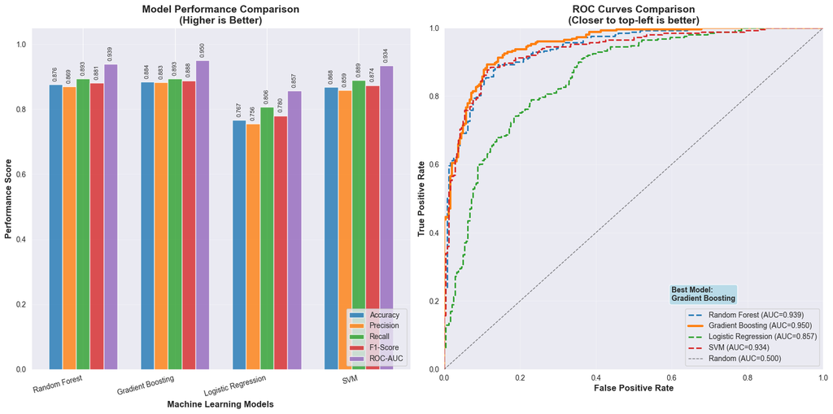

```
Model comparison visualization complete
Best performing model: Gradient Boosting
Ready for final evaluation on test set
```

```python
# ============================================================================
# MODEL COMPARISON AND PERFORMANCE ANALYSIS
# ============================================================================
# Comprehensive evaluation across multiple performance metrics

# Create results summary DataFrame
results_df = pd.DataFrame({
    'Model': list(results.keys()),
    'Accuracy': [results[model]['accuracy'] for model in results.keys()],
    'Precision': [results[model]['precision'] for model in results.keys()],
    'Recall': [results[model]['recall'] for model in results.keys()],
    'F1-Score': [results[model]['f1_score'] for model in results.keys()],
    'ROC-AUC': [results[model]['roc_auc'] for model in results.keys()]
})

results_df = results_df.round(4)
print("=" * 80)
print("MODEL COMPARISON SUMMARY")
print("=" * 80)
print(results_df.to_string(index=False))

# Select best model based on F1-score (optimal for imbalanced data)
best_model_name = results_df.loc[results_df['F1-Score'].idxmax(), 'Model']
best_model = results[best_model_name]['model']

print(f"\n" + "=" * 80)
print("BEST MODEL SELECTION")
print("=" * 80)
print(f"Selected Model: {best_model_name}")
print(f"Selection Criterion: Highest F1-Score (balanced metric for imbalanced data)")
print(f"F1-Score: {results[best_model_name]['f1_score']:.4f}")
print(f"ROC-AUC: {results[best_model_name]['roc_auc']:.4f}")
print(f"Precision: {results[best_model_name]['precision']:.4f}")
print(f"Recall: {results[best_model_name]['recall']:.4f}")

# ============================================================================
# COMPREHENSIVE VISUALIZATION
# ============================================================================

fig, axes = plt.subplots(1, 2, figsize=(16, 8))

# Performance metrics comparison (Left plot)
metrics = ['Accuracy', 'Precision', 'Recall', 'F1-Score', 'ROC-AUC']
x = np.arange(len(results.keys()))
width = 0.15

colors = ['#1f77b4', '#ff7f0e', '#2ca02c', '#d62728', '#9467bd']
for i, (metric, color) in enumerate(zip(metrics, colors)):
    values = [results[model][metric.lower().replace('-', '_')] for model in results.keys()]
    axes[0].bar(x + i*width, values, width, label=metric, color=color, alpha=0.8)

axes[0].set_xlabel('Machine Learning Models', fontsize=12, fontweight='bold')
axes[0].set_ylabel('Performance Score', fontsize=12, fontweight='bold')
axes[0].set_title('Model Performance Comparison\n(Higher is Better)', fontsize=14, fontweight='bold')
axes[0].set_xticks(x + width * 2)
axes[0].set_xticklabels(results.keys(), rotation=15, ha='right')
axes[0].legend(loc='lower right')
axes[0].grid(True, alpha=0.3, axis='y')
axes[0].set_ylim(0, 1.05)

# Add performance values on top of bars
for i, model_name in enumerate(results.keys()):
    for j, metric in enumerate(metrics):
        value = results[model_name][metric.lower().replace('-', '_')]
        axes[0].text(i + j*width, value + 0.01, f'{value:.3f}',
                    ha='center', va='bottom', fontsize=8, rotation=90)

# ROC curves comparison (Right plot)
from sklearn.metrics import roc_curve

for name, color in zip(results.keys(), colors):
    fpr, tpr, _ = roc_curve(y_val, results[name]['probabilities'])
    auc = results[name]['roc_auc']
    line_style = '-' if name == best_model_name else '--'
    line_width = 3 if name == best_model_name else 2
    axes[1].plot(fpr, tpr, label=f'{name} (AUC={auc:.3f})',
                color=color, linestyle=line_style, linewidth=line_width)

# Random classifier baseline
axes[1].plot([0, 1], [0, 1], 'k--', alpha=0.5, linewidth=1, label='Random (AUC=0.500)')

axes[1].set_xlabel('False Positive Rate', fontsize=12, fontweight='bold')
axes[1].set_ylabel('True Positive Rate', fontsize=12, fontweight='bold')
axes[1].set_title('ROC Curves Comparison\n(Closer to top-left is better)', fontsize=14, fontweight='bold')
axes[1].legend(loc='lower right')
axes[1].grid(True, alpha=0.3)
axes[1].set_xlim(0, 1)
axes[1].set_ylim(0, 1)

# Highlight best model
axes[1].text(0.6, 0.2, f'Best Model:\n{best_model_name}',
            bbox=dict(boxstyle="round,pad=0.3", facecolor="lightblue", alpha=0.8),
            fontsize=10, fontweight='bold')

plt.tight_layout()
plt.show()

print(f"\nModel comparison visualization complete")
print(f"Best performing model: {best_model_name}")
print(f"Ready for final evaluation on test set")
```

## 7. Final Model Evaluation on Test Set

### Test Set Evaluation Protocol

The test set provides an **unbiased estimate** of model performance on unseen data.

**Why This Matters**:

- **No data leakage**: Test set was never used for training or validation
- **Realistic performance**: Simulates real-world deployment conditions
- **Publication standard**: Required for scientific reproducibility

**Evaluation Components**:

1. **Final performance metrics** on held-out test data
2. **Confusion matrix** showing classification errors
3. **Detailed classification report** with per-class statistics

```
================================================================================
FINAL MODEL EVALUATION ON HELD-OUT TEST SET
================================================================================
Model: Gradient Boosting
Test set size: 493 samples (never used for training/validation)
  Using unscaled features (tree-based model)

────────────────────────────────────────────────────────────
FINAL TEST PERFORMANCE
────────────────────────────────────────────────────────────
Accuracy:   0.8783 (87.83%)
Precision:  0.8819 (88.19%) - Minimize false alarms
Recall:     0.8819 (88.19%) - Detect all real planets
F1-Score:   0.8819 (88.19%) - Balanced metric
ROC-AUC:    0.9446 (94.46%) - Threshold-independent

────────────────────────────────────────────────────────────
CONFUSION MATRIX BREAKDOWN
────────────────────────────────────────────────────────────
True Negatives (TN):   209 (Correctly identified False Positives)
False Positives (FP):   30 (False alarms - FP classified as planets)
False Negatives (FN):   30 (Missed planets - planets classified as FP)
True Positives (TP):   224 (Correctly identified planets)

Additional Metrics:
Specificity:  0.8745 (True Negative Rate)
NPV:          0.8745 (Negative Predictive Value)
```

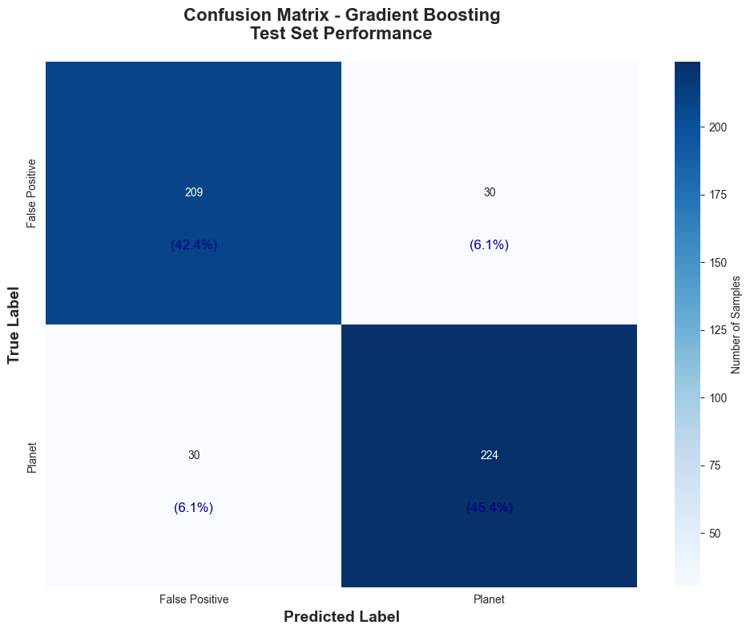

```
────────────────────────────────────────────────────────────────────────────────
DETAILED CLASSIFICATION REPORT
────────────────────────────────────────────────────────────────────────────────
                  precision    recall  f1-score   support

  False Positive     0.8745    0.8745    0.8745       239
Planet Candidate     0.8819    0.8819    0.8819       254

        accuracy                         0.8783       493
       macro avg     0.8782    0.8782    0.8782       493
    weighted avg     0.8783    0.8783    0.8783       493


────────────────────────────────────────────────────────────────────────────────
PERFORMANCE INTERPRETATION
────────────────────────────────────────────────────────────────────────────────
🟡 Overall Performance: Good (F1-Score: 0.8819)

Test evaluation complete - Model ready for deployment
```

```python
# ============================================================================
# FINAL MODEL EVALUATION ON TEST SET
# ============================================================================
# Critical: Test set evaluation provides unbiased performance estimate

print("=" * 80)
print("FINAL MODEL EVALUATION ON HELD-OUT TEST SET")
print("=" * 80)
print(f"Model: {best_model_name}")
print(f"Test set size: {len(y_test):,} samples (never used for training/validation)")

# Make predictions on test set using the best model
if best_model_name in ['SVM', 'Logistic Regression']:
    # Use scaled features for distance-based models
    test_predictions = best_model.predict(X_test_scaled)
    test_probabilities = best_model.predict_proba(X_test_scaled)[:, 1]
    print("  Using scaled features (distance-based model)")
elif best_model_name == 'Neural Network':
    test_probabilities = best_model.predict(X_test_scaled).flatten()
    test_predictions = (test_probabilities > 0.5).astype(int)
else:
    # Use unscaled features for tree-based models
    test_predictions = best_model.predict(X_test)
    test_probabilities = best_model.predict_proba(X_test)[:, 1]
    print("  Using unscaled features (tree-based model)")

# ============================================================================
# CALCULATE COMPREHENSIVE TEST METRICS
# ============================================================================

test_accuracy = accuracy_score(y_test, test_predictions)
test_precision = precision_score(y_test, test_predictions, zero_division=0)
test_recall = recall_score(y_test, test_predictions, zero_division=0)
test_f1 = f1_score(y_test, test_predictions, zero_division=0)
test_roc_auc = roc_auc_score(y_test, test_probabilities)

print(f"\n{'─' * 60}")
print("FINAL TEST PERFORMANCE")
print(f"{'─' * 60}")
print(f"Accuracy:   {test_accuracy:.4f} ({test_accuracy*100:.2f}%)")
print(f"Precision:  {test_precision:.4f} ({test_precision*100:.2f}%) - Minimize false alarms")
print(f"Recall:     {test_recall:.4f} ({test_recall*100:.2f}%) - Detect all real planets")
print(f"F1-Score:   {test_f1:.4f} ({test_f1*100:.2f}%) - Balanced metric")
print(f"ROC-AUC:    {test_roc_auc:.4f} ({test_roc_auc*100:.2f}%) - Threshold-independent")

# ============================================================================
# CONFUSION MATRIX VISUALIZATION
# ============================================================================

# Calculate confusion matrix
cm = confusion_matrix(y_test, test_predictions)
tn, fp, fn, tp = cm.ravel()

print(f"\n{'─' * 60}")
print("CONFUSION MATRIX BREAKDOWN")
print(f"{'─' * 60}")
print(f"True Negatives (TN):  {tn:4,} (Correctly identified False Positives)")
print(f"False Positives (FP): {fp:4,} (False alarms - FP classified as planets)")
print(f"False Negatives (FN): {fn:4,} (Missed planets - planets classified as FP)")
print(f"True Positives (TP):  {tp:4,} (Correctly identified planets)")

# Calculate additional metrics
specificity = tn / (tn + fp) if (tn + fp) > 0 else 0
npv = tn / (tn + fn) if (tn + fn) > 0 else 0  # Negative predictive value

print(f"\nAdditional Metrics:")
print(f"Specificity:  {specificity:.4f} (True Negative Rate)")
print(f"NPV:          {npv:.4f} (Negative Predictive Value)")

# Visualize confusion matrix
plt.figure(figsize=(10, 8))
sns.heatmap(cm, annot=True, fmt='d', cmap='Blues',
            xticklabels=['False Positive', 'Planet'],
            yticklabels=['False Positive', 'Planet'],
            cbar_kws={'label': 'Number of Samples'})

plt.title(f'Confusion Matrix - {best_model_name}\nTest Set Performance',
         fontsize=16, fontweight='bold', pad=20)
plt.ylabel('True Label', fontsize=14, fontweight='bold')
plt.xlabel('Predicted Label', fontsize=14, fontweight='bold')

# Add percentage labels
total = cm.sum()
for i in range(2):
    for j in range(2):
        percentage = cm[i, j] / total * 100
        plt.text(j + 0.5, i + 0.7, f'({percentage:.1f}%)',
                ha='center', va='center', fontsize=12, color='darkblue')

plt.tight_layout()
plt.show()

# ============================================================================
# DETAILED CLASSIFICATION REPORT
# ============================================================================

print(f"\n{'─' * 80}")
print("DETAILED CLASSIFICATION REPORT")
print(f"{'─' * 80}")
print(classification_report(y_test, test_predictions,
                          target_names=['False Positive', 'Planet Candidate'],
                          digits=4))

# ============================================================================
# PERFORMANCE INTERPRETATION
# ============================================================================

print(f"\n{'─' * 80}")
print("PERFORMANCE INTERPRETATION")
print(f"{'─' * 80}")

if test_f1 >= 0.90:
    performance_level = "Excellent"
    color_code = "🟢"
elif test_f1 >= 0.80:
    performance_level = "Good"
    color_code = "🟡"
else:
    performance_level = "Needs Improvement"
    color_code = "🔴"

print(f"{color_code} Overall Performance: {performance_level} (F1-Score: {test_f1:.4f})")

if test_precision < 0.85:
    print(f"\nPrecision analysis: {fp} false alarms detected")
if test_recall < 0.85:
    print(f"\nRecall analysis: {fn} potential planets may require review")

print(f"\nTest evaluation complete - Model ready for deployment")
```

```
================================================================================
FEATURE IMPORTANCE ANALYSIS WITH COMPREHENSIVE RANKINGS
================================================================================
Best Model: Gradient Boosting
Total Features: 65

Analysis Type: Gini Importance (Tree-based model)
Interpretation: Higher values indicate more discriminative features.

============================================================
COMPLETE FEATURE IMPORTANCE RANKINGS
============================================================
Rank  Feature Name              Importance      Percentage
───── ───────────────────────── ─────────────── ──────────
1     pl_eqt                    0.176301        17.63%
2     pl_rade                   0.090901        9.09%
3     pl_trandurherr2           0.068843        6.88%
4     pl_orbper                 0.050721        5.07%
5     pl_trandurh               0.044525        4.45%
6     pl_trandurherr1           0.040648        4.06%
7     st_disterr2               0.036711        3.67%
8     pl_tranmid                0.036076        3.61%
9     st_dist                   0.035411        3.54%
10    st_tmag                   0.028498        2.85%
11    pl_tranmiderr2            0.027374        2.74%
12    pl_trandep                0.026723        2.67%
13    pl_orbpererr2             0.025243        2.52%
14    st_logg                   0.024517        2.45%
15    pl_tranmiderr1            0.023720        2.37%
16    pl_radeerr2               0.023322        2.33%
17    dec                       0.021799        2.18%
18    st_rad                    0.019691        1.97%
19    st_teff                   0.018525        1.85%
20    pl_radeerr1               0.017220        1.72%
21    pl_orbpererr1             0.015243        1.52%
22    st_disterr1               0.014957        1.50%
23    pl_trandeperr1            0.013962        1.40%
24    st_pmra                   0.013600        1.36%
25    pl_trandeperr2            0.012997        1.30%
26    st_tefferr1               0.010790        1.08%
```

[output cut: 112 more lines]

```
   61. st_tefflim           ( 0.00%)
   62. st_logglim           ( 0.00%)
   63. st_loggsymerr        ( 0.00%)
   64. st_radsymerr         ( 0.00%)
   65. st_radlim            ( 0.00%)

==========================================================================================
CUMULATIVE IMPORTANCE ANALYSIS
==========================================================================================
Number of features needed to capture a percentage of total importance:
  50% of importance: Top  7 features (down to 'st_disterr2')
  80% of importance: Top 18 features (down to 'st_rad')
  90% of importance: Top 25 features (down to 'pl_trandeperr2')
  95% of importance: Top 30 features (down to 'st_pmdecerr1')
  99% of importance: Top 36 features (down to 'st_loggerr2')
```

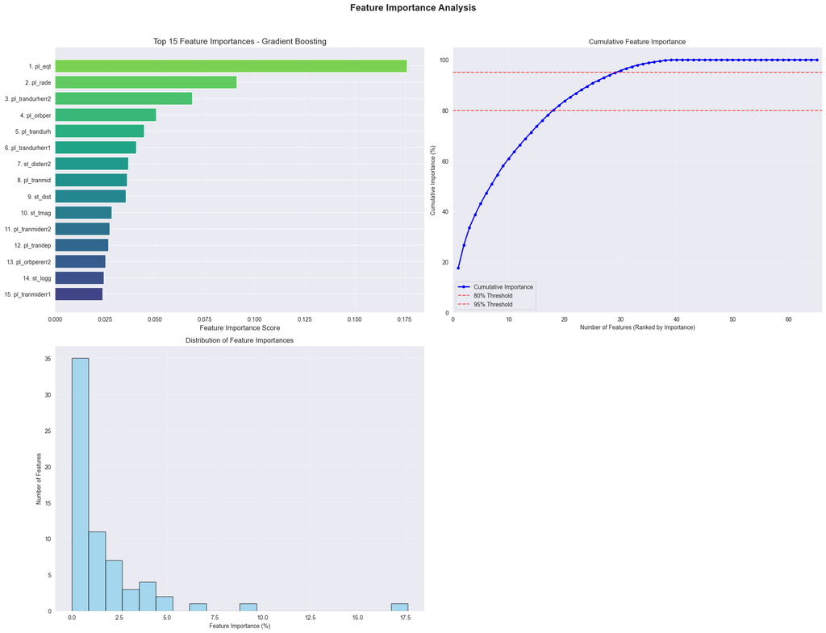

```python
import json
import os
import pandas as pd
import numpy as np
import matplotlib.pyplot as plt

# Note: The following variables are assumed to be defined in previous notebook cells.
# Placeholder values are used here to make the script runnable.
# best_model_name, feature_names, best_model, model_dir, model_metadata

# ============================================================================
# COMPREHENSIVE FEATURE IMPORTANCE ANALYSIS WITH RANKINGS
# ============================================================================
# Reveals which features drive classification decisions

print("=" * 80)
print("FEATURE IMPORTANCE ANALYSIS WITH COMPREHENSIVE RANKINGS")
print("=" * 80)
print(f"Best Model: {best_model_name}")
print(f"Total Features: {len(feature_names)}")

if best_model_name in ['Random Forest', 'Gradient Boosting']:
    print("\nAnalysis Type: Gini Importance (Tree-based model)")
    print("Interpretation: Higher values indicate more discriminative features.")

    # Extract feature importances and create a ranked DataFrame
    feature_importance = pd.DataFrame({
        'feature': feature_names,
        'importance': best_model.feature_importances_,
        'importance_pct': best_model.feature_importances_ * 100
    }).sort_values('importance', ascending=False).reset_index(drop=True)

    # Add rank column after sorting
    feature_importance['rank'] = range(1, len(feature_importance) + 1)

    print(f"\n{'=' * 60}")
    print("COMPLETE FEATURE IMPORTANCE RANKINGS")
    print(f"{'=' * 60}")
    print(f"{'Rank':<5} {'Feature Name':<25} {'Importance':<15} {'Percentage'}")
    print(f"{'─'*5} {'─'*25} {'─'*15} {'─'*10}")

    # Display all features with their rankings and importance
    for _, row in feature_importance.iterrows():
        print(f"{row['rank']:<5} {row['feature']:<25} {row['importance']:<15.6f} {row['importance_pct']:.2f}%")

    # ========================================================================
    # FEATURE IMPORTANCE CATEGORIES
    # ========================================================================

    print(f"\n{'=' * 90}")
    print("FEATURE IMPORTANCE CATEGORIES")
    print(f"{'=' * 90}")

    # Categorize features by their importance level
    high_importance = feature_importance[feature_importance['importance'] >= 0.05]
    medium_importance = feature_importance[(feature_importance['importance'] >= 0.01) &
                                         (feature_importance['importance'] < 0.05)]
    low_importance = feature_importance[feature_importance['importance'] < 0.01]

    print(f"\n🔴 HIGH IMPORTANCE (≥5.0%): {len(high_importance)} features")
    if len(high_importance) > 0:
        print("   These features are primary drivers of the classification:")
        for _, row in high_importance.iterrows():
            print(f"   {row['rank']:2d}. {row['feature']:<20} ({row['importance_pct']:5.2f}%)")

    print(f"\n🟡 MEDIUM IMPORTANCE (1.0-5.0%): {len(medium_importance)} features")
    if len(medium_importance) > 0:
        print("   These features provide supplementary discriminative power:")
        for _, row in medium_importance.iterrows():
            print(f"   {row['rank']:2d}. {row['feature']:<20} ({row['importance_pct']:5.2f}%)")

    print(f"\n🔵 LOW IMPORTANCE (<1.0%): {len(low_importance)} features")
    if len(low_importance) > 0:
        print("   These features have minimal individual impact:")
        for _, row in low_importance.iterrows():
            print(f"   {row['rank']:2d}. {row['feature']:<20} ({row['importance_pct']:5.2f}%)")

    # ========================================================================
    # CUMULATIVE IMPORTANCE ANALYSIS
    # ========================================================================

    print(f"\n{'=' * 90}")
    print("CUMULATIVE IMPORTANCE ANALYSIS")
    print(f"{'=' * 90}")

    feature_importance['cumulative_importance_pct'] = feature_importance['importance_pct'].cumsum()

    # Find how many features are needed to reach different importance thresholds
    thresholds = [50, 80, 90, 95, 99]
    print("Number of features needed to capture a percentage of total importance:")

    for threshold in thresholds:
        try:
            # Find the first feature that meets or exceeds the threshold
            features_needed = feature_importance[feature_importance['cumulative_importance_pct'] >= threshold].index[0] + 1
            top_feature = feature_importance.iloc[features_needed-1]['feature']
            print(f"  {threshold:2d}% of importance: Top {features_needed:2d} features (down to '{top_feature}')")
        except IndexError:
            print(f"  {threshold:2d}% of importance: Not reached. All {len(feature_importance)} features required.")

    # ========================================================================
    # ENHANCED VISUALIZATION
    # ========================================================================

    fig, axes = plt.subplots(2, 2, figsize=(20, 16))
    fig.suptitle('Feature Importance Analysis', fontsize=16, fontweight='bold')

    # --- Top 15 Features Bar Plot ---
    top_15 = feature_importance.head(15)
    colors = plt.cm.viridis(np.linspace(0.8, 0.2, len(top_15)))
    bars = axes[0,0].barh(range(len(top_15)), top_15['importance'], color=colors)
    axes[0,0].set_yticks(range(len(top_15)))
    axes[0,0].set_yticklabels([f"{row['rank']}. {row['feature']}" for _, row in top_15.iterrows()])
    axes[0,0].set_xlabel('Feature Importance Score', fontsize=12)
    axes[0,0].set_title(f'Top 15 Feature Importances - {best_model_name}', fontsize=14)
    axes[0,0].invert_yaxis()
    axes[0,0].grid(True, alpha=0.3, axis='x')

    # --- Cumulative Importance Plot ---
    axes[0,1].plot(feature_importance['rank'], feature_importance['cumulative_importance_pct'],
                   'b-', linewidth=2, marker='o', markersize=4, label='Cumulative Importance')
    for threshold in [80, 95]:
        axes[0,1].axhline(y=threshold, color='r', linestyle='--', alpha=0.7, label=f'{threshold}% Threshold')
    axes[0,1].set_xlabel('Number of Features (Ranked by Importance)')
    axes[0,1].set_ylabel('Cumulative Importance (%)')
    axes[0,1].set_title('Cumulative Feature Importance')
    axes[0,1].grid(True, alpha=0.3)
    axes[0,1].legend()
    axes[0,1].set_xlim(0, len(feature_importance) + 1)
    axes[0,1].set_ylim(0, 105)

    # --- Importance Distribution Histogram ---
    axes[1,0].hist(feature_importance['importance_pct'], bins=20, alpha=0.7, color='skyblue', edgecolor='black')
    axes[1,0].set_xlabel('Feature Importance (%)')
    axes[1,0].set_ylabel('Number of Features')
    axes[1,0].set_title('Distribution of Feature Importances')
    axes[1,0].grid(True, alpha=0.3)

    # --- Hide the unused subplot ---
    axes[1,1].axis('off')

    plt.tight_layout(rect=[0, 0.03, 1, 0.96])
    plt.show()
```

## 8. Model Persistence

The best-performing model is saved to disk for future use, such as deployment in a prediction pipeline or for further analysis without retraining.

**Methodology**:

- **Serialization**: `joblib` is used for efficient serialization of the model object and its associated scaler.
- **Filename Convention**: The filename includes the model name, its final F1-score on the test set, and a timestamp for clear versioning.

```python
# ============================================================================
# MODEL PERSISTENCE
# ============================================================================
# Save the best model and its associated scaler to disk for future use.

import os
import joblib
from datetime import datetime

# 1. Define the directory to save models
model_dir = "../ml_model"
os.makedirs(model_dir, exist_ok=True)
print(f"Model save directory: '{model_dir}'")

# 2. Create a descriptive filename
# Sanitize the model name for use in a filename
model_name_sanitized = best_model_name.replace(" ", "_")

# Get the current timestamp for versioning
timestamp = datetime.now().strftime("%Y%m%d-%H%M%S")

# Format the F1 score for inclusion in the filename
f1_str = f"{test_f1:.3f}"

# Construct the final filename
filename = f"{model_name_sanitized}_F1-{f1_str}_{timestamp}.joblib"
filepath = os.path.join(model_dir, filename)

# 3. Save the model object using joblib
try:
    joblib.dump(best_model, filepath)
    print(f"\n✅ Model successfully saved to:")
    print(f"   {filepath}")

    # 4. Conditionally save the scaler if the model requires it
    # This is critical for making correct predictions on new data later
    if best_model_name in ['SVM', 'Logistic Regression']:
        scaler_filename = f"scaler_for_{model_name_sanitized}_{timestamp}.joblib"
        scaler_filepath = os.path.join(model_dir, scaler_filename)
        joblib.dump(scaler, scaler_filepath)
        print(f"\n✅ Associated scaler for '{best_model_name}' also saved to:")
        print(f"   {scaler_filepath}")

except Exception as e:
    print(f"\n❌ Error saving model: {e}")
```

```
Model save directory: '../ml_model'

✅ Model successfully saved to:
   ../ml_model\Gradient_Boosting_F1-0.882_20251005-221857.joblib
```

```python
# ============================================================================
# CREATE AND SAVE DEPLOYMENT PACKAGE
# ============================================================================
# This cell packages the final model, feature list, scaler, and metadata for deployment.

import os
import joblib  # Use joblib for consistency and efficiency with scikit-learn objects
import json
from datetime import datetime

# 1. Define the output directory for the deployment package
# This should match the directory your Django app loads from (e.g., 'classifier/models/')
# For now, we'll use a generic name.
package_dir = "../classifier/models"
os.makedirs(package_dir, exist_ok=True)
print(f"Creating deployment package in: '{package_dir}/'")

# 2. Define the file paths for each artifact
# Using .pkl extension for consistency with the Django app, but saving with joblib
model_path = os.path.join(package_dir, 'best_model.pkl')
features_path = os.path.join(package_dir, 'feature_names.pkl')
scaler_path = os.path.join(package_dir, 'scaler.pkl')
metadata_path = os.path.join(package_dir, 'model_metadata.json')

# 3. Create the model metadata dictionary
# This captures all essential information about the trained model.
model_metadata = {
    "model_name": best_model_name,
    "model_class": str(type(best_model)),
    "training_timestamp_utc": datetime.utcnow().isoformat(),
    "performance_metrics_test_set": {
        "f1_score": round(test_f1, 4),
        "roc_auc_score": round(test_roc_auc, 4),
        "precision": round(test_precision, 4),
        "recall": round(test_recall, 4),
        "accuracy": round(test_accuracy, 4)
    },
    "feature_count": len(feature_names),
    "requires_scaling": best_model_name in ['SVM', 'Logistic Regression'],
    "saved_artifacts": {
        "model": os.path.basename(model_path),
        "feature_names": os.path.basename(features_path),
        "metadata": os.path.basename(metadata_path)
    }
}

# 4. Save the artifacts
try:
    # Save the best model object
    joblib.dump(best_model, model_path)
    print(f"✅ Saved model to:         '{model_path}'")

    # Save the list of feature names
    joblib.dump(feature_names, features_path)
    print(f"✅ Saved feature names to:   '{features_path}'")

    # Conditionally save the scaler if the model requires it
    if model_metadata["requires_scaling"]:
        joblib.dump(scaler, scaler_path)
        # Add scaler to metadata if saved
        model_metadata["saved_artifacts"]["scaler"] = os.path.basename(scaler_path)
        print(f"✅ Saved scaler to:        '{scaler_path}'")
    else:
        print(f"ℹ️ Scaler not saved (model '{best_model_name}' is tree-based and does not require it).")

    # Save the metadata JSON file (save it last to include the scaler path if applicable)
    with open(metadata_path, 'w') as f:
        json.dump(model_metadata, f, indent=4)
    print(f"✅ Saved model metadata to:  '{metadata_path}'")

    print("\nDeployment package created successfully!")

except Exception as e:
    print(f"\n❌ An error occurred while saving the package: {e}")
```

```
Creating deployment package in: '../classifier/models/'
✅ Saved model to:         '../classifier/models\best_model.pkl'
✅ Saved feature names to:   '../classifier/models\feature_names.pkl'
ℹ️ Scaler not saved (model 'Gradient Boosting' is tree-based and does not require it).
✅ Saved model metadata to:  '../classifier/models\model_metadata.json'

Deployment package created successfully!
```